# Plots from Simulations (500 reps)

## GA4 - Both values (max-min)

**Density**

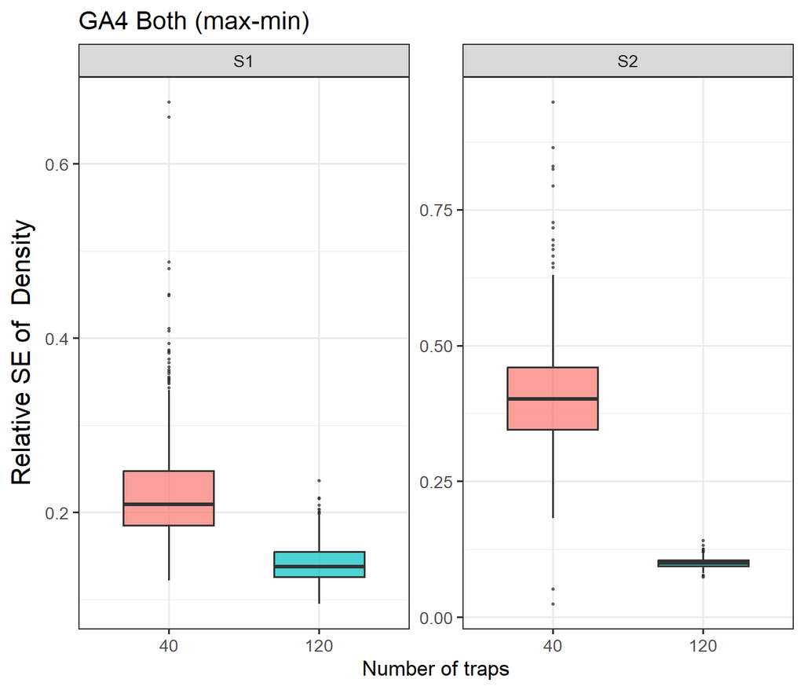

**λ₀**

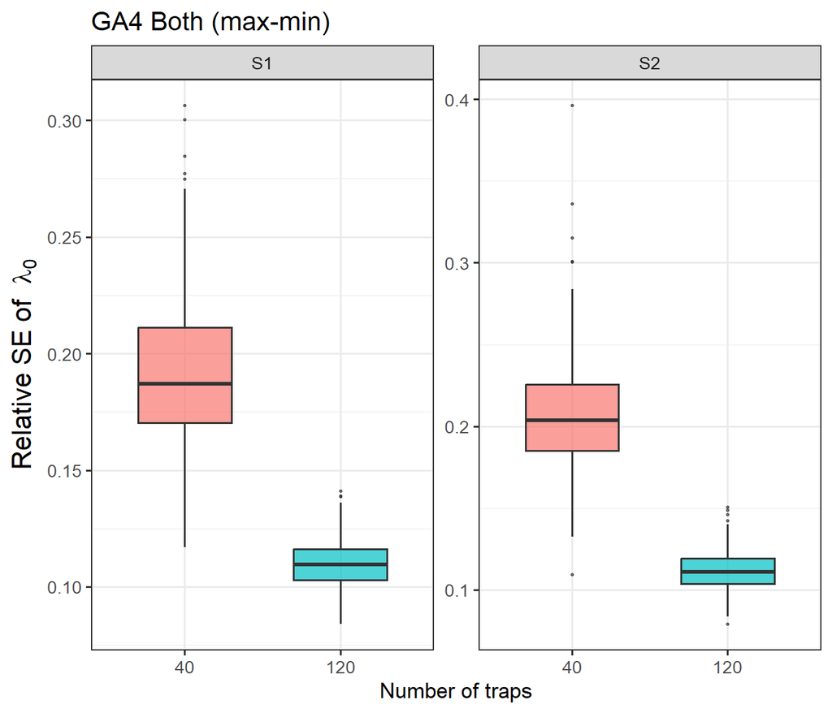

**σ**

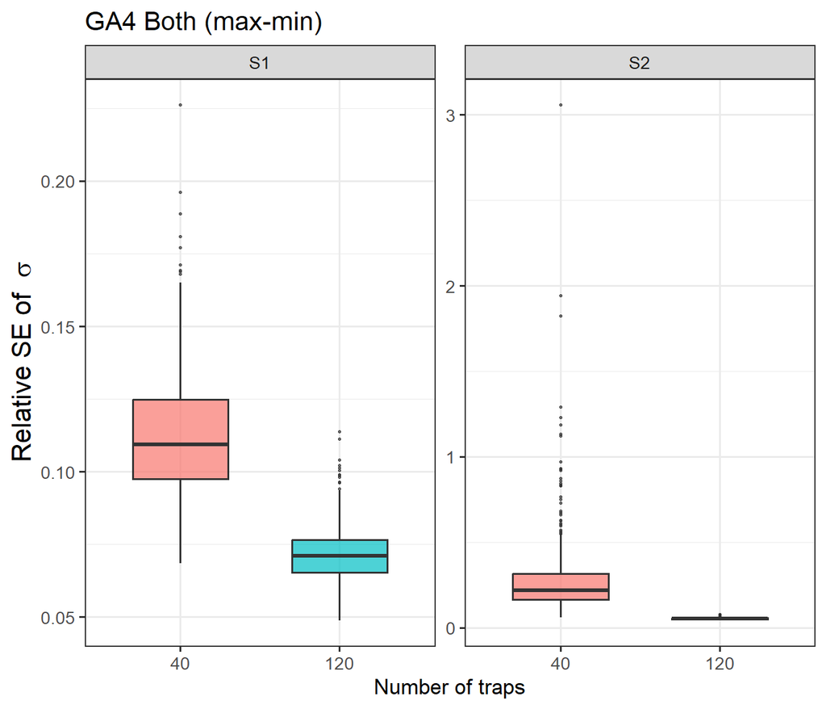

## GA5 - S1 values

**Density**

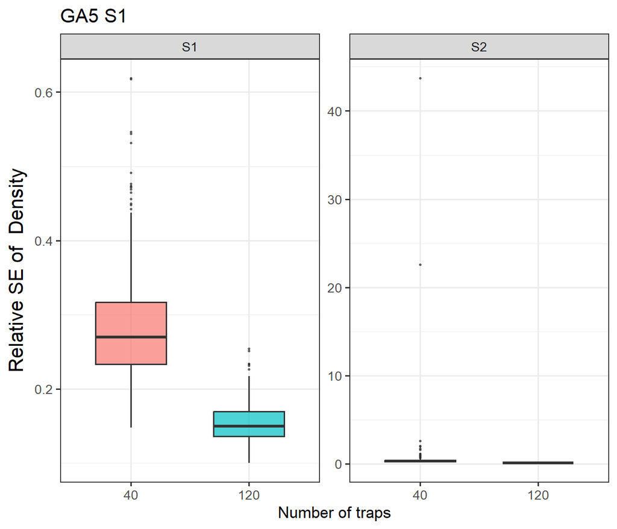

**λ₀**

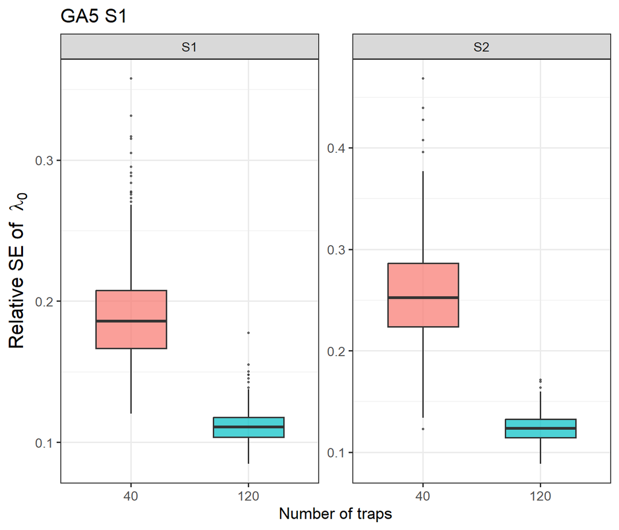

**σ**

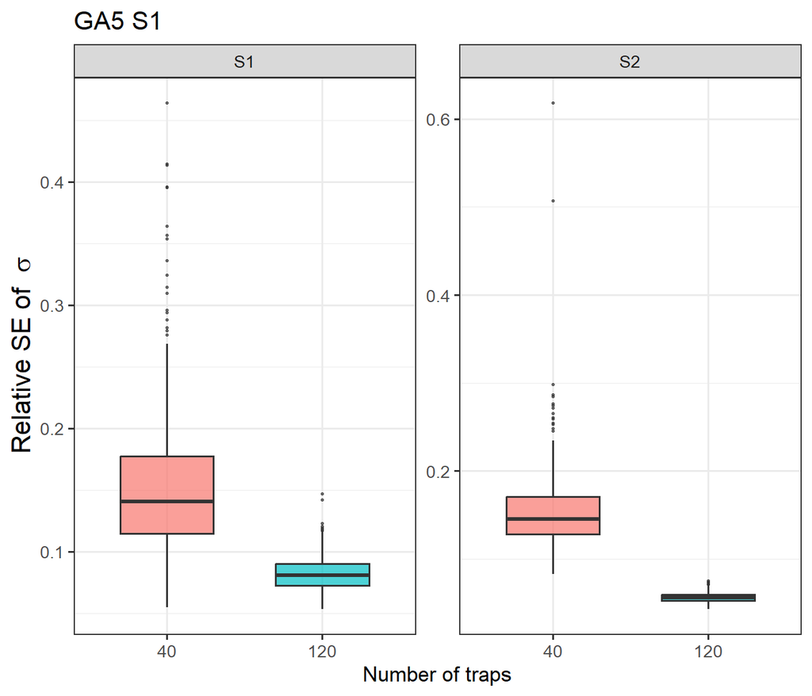

## GA5 - S2 values

**Density**

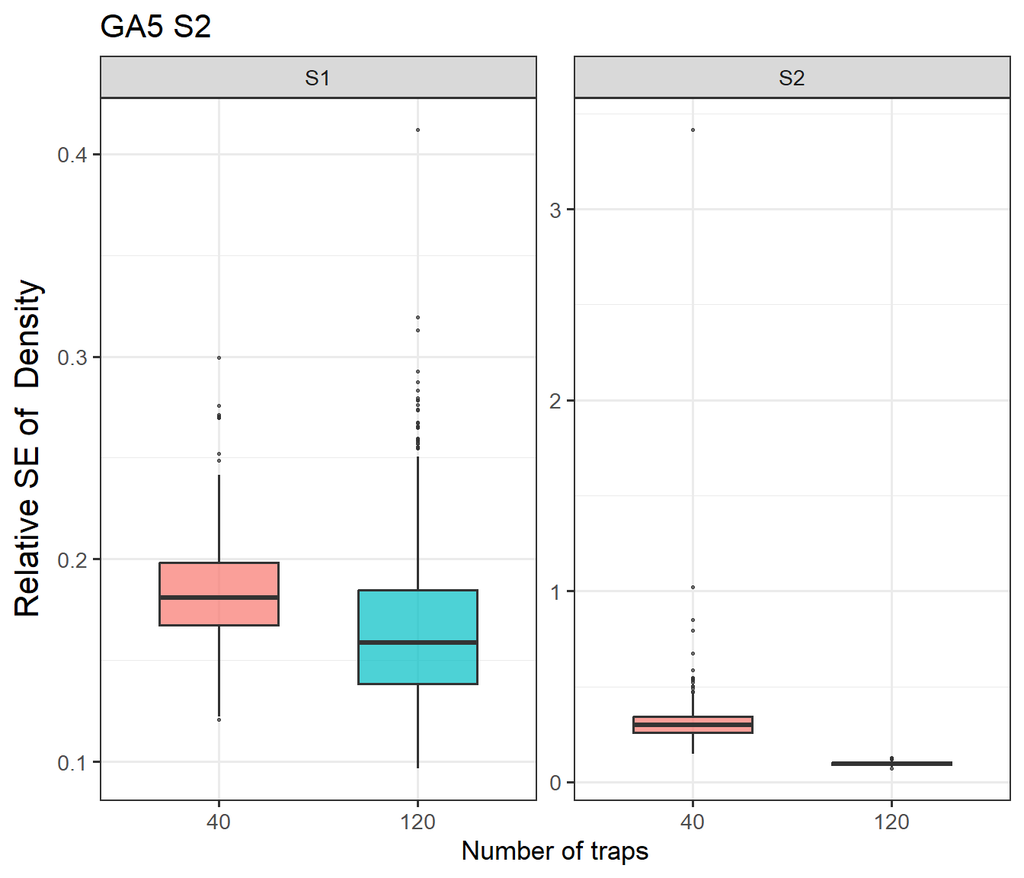

**λ₀**

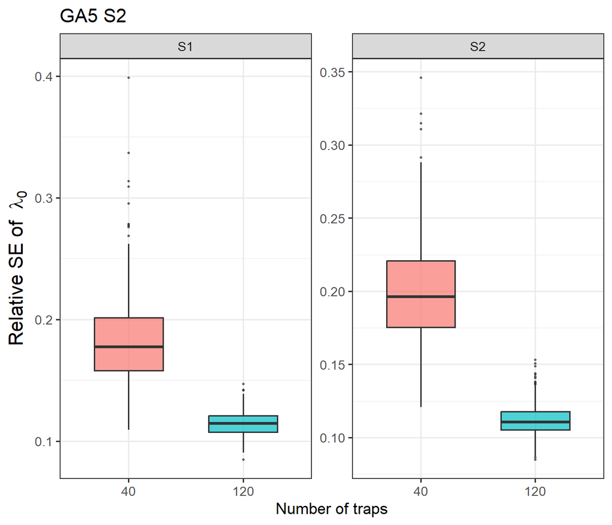

**σ**

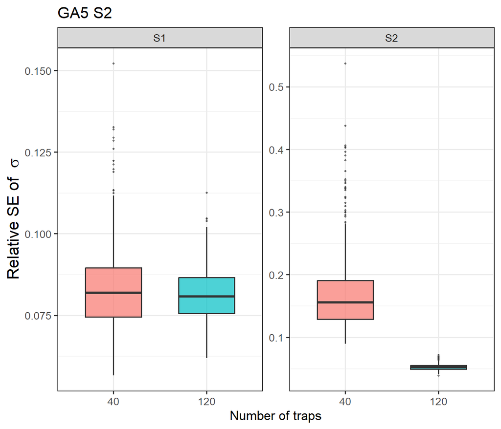

## GA5 - Avg values

**Density**

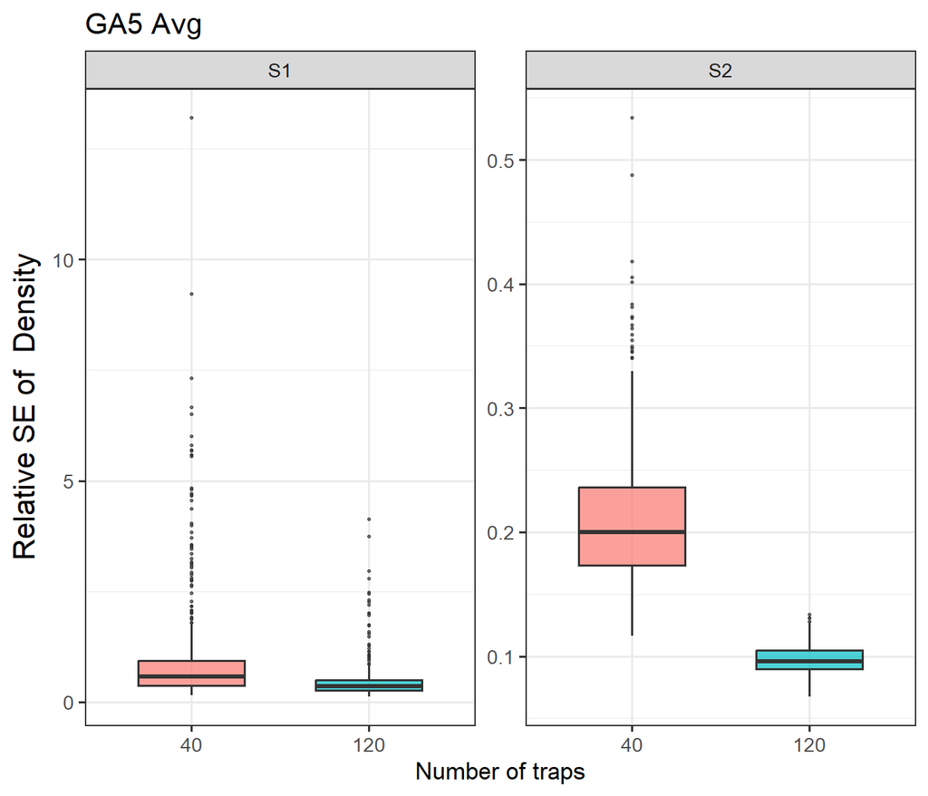

**λ₀**

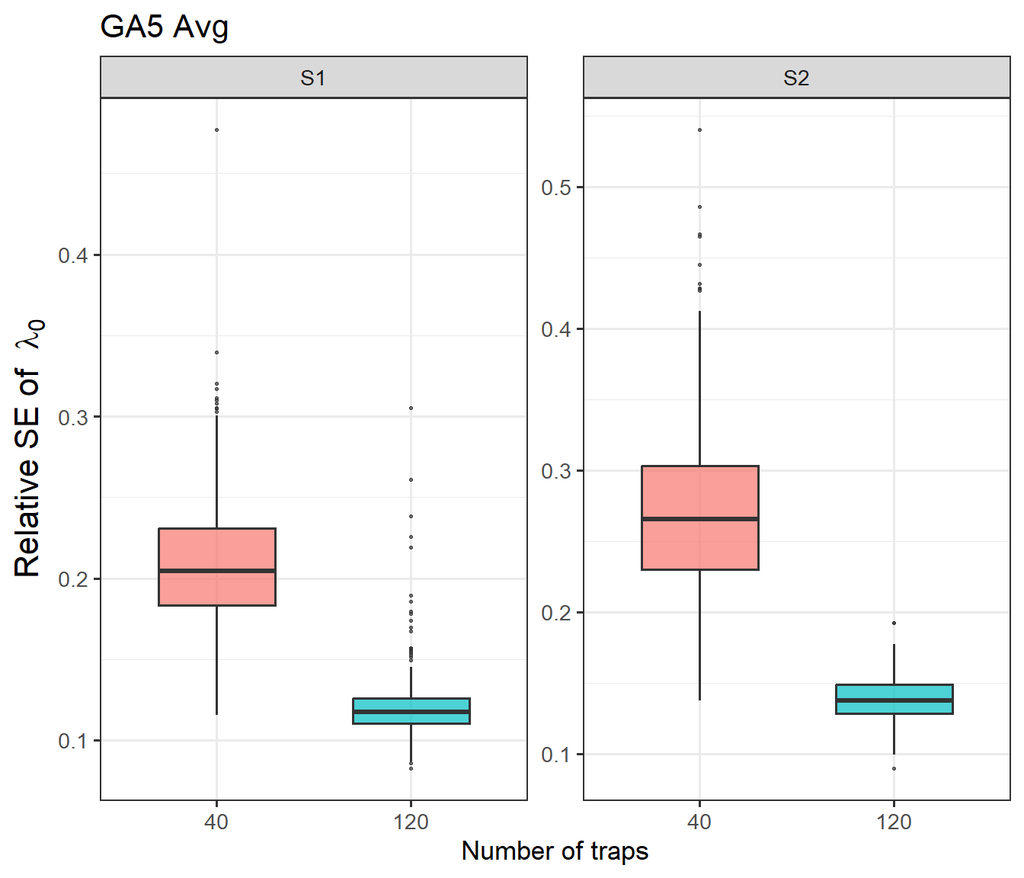

**σ**

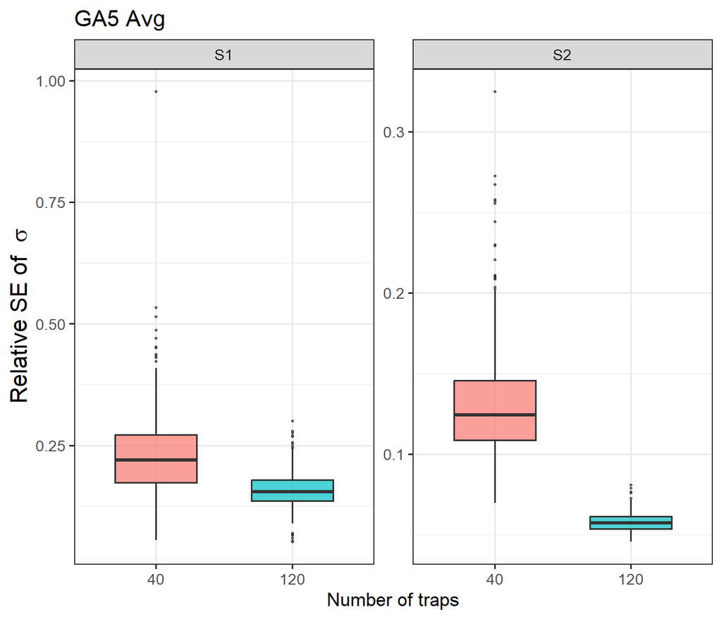

## GA5 - Both values

**Density**

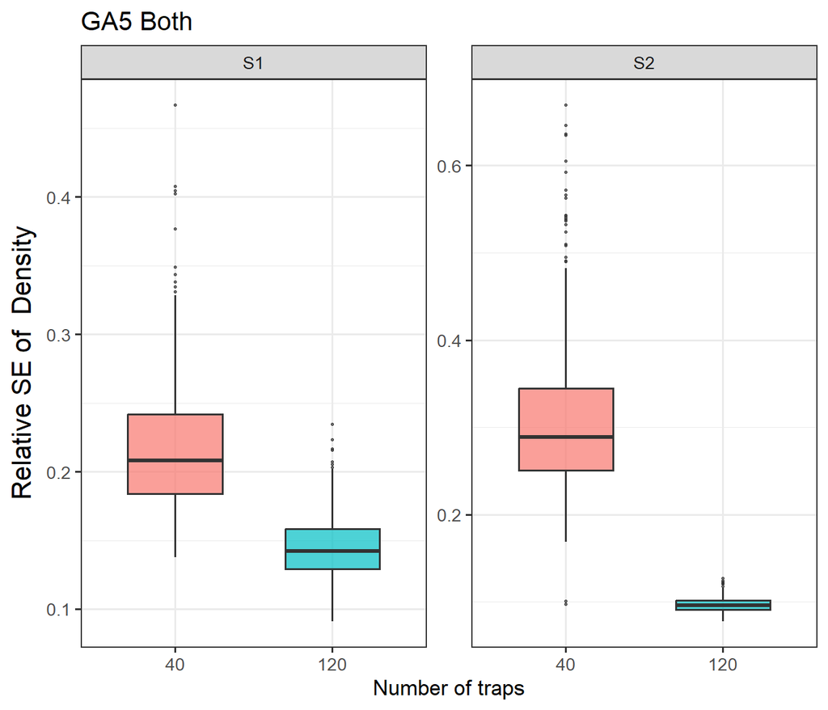

**λ₀**

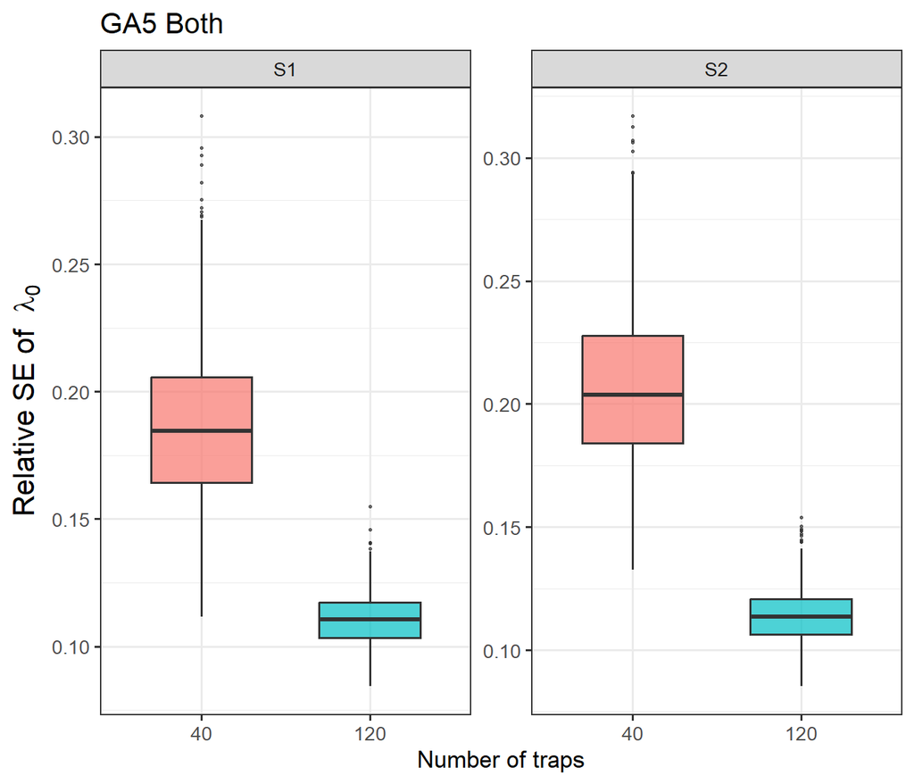

**σ**

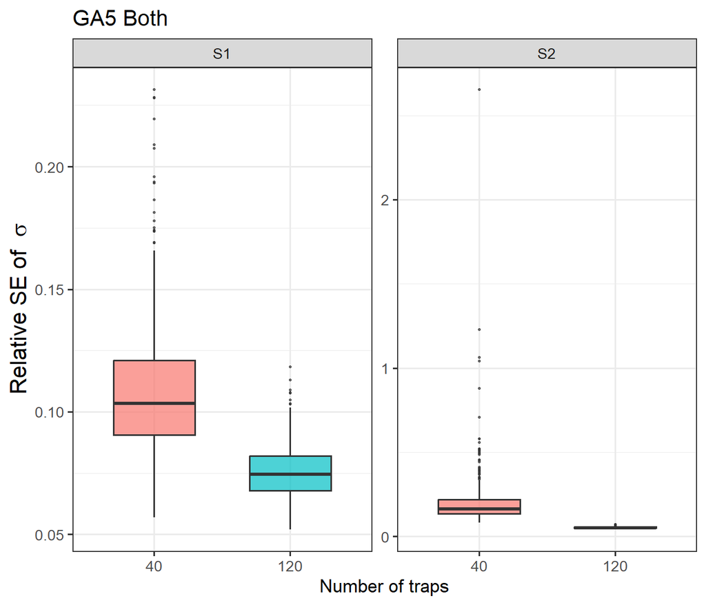

## GA5 - Both values (max-min)

**Density**

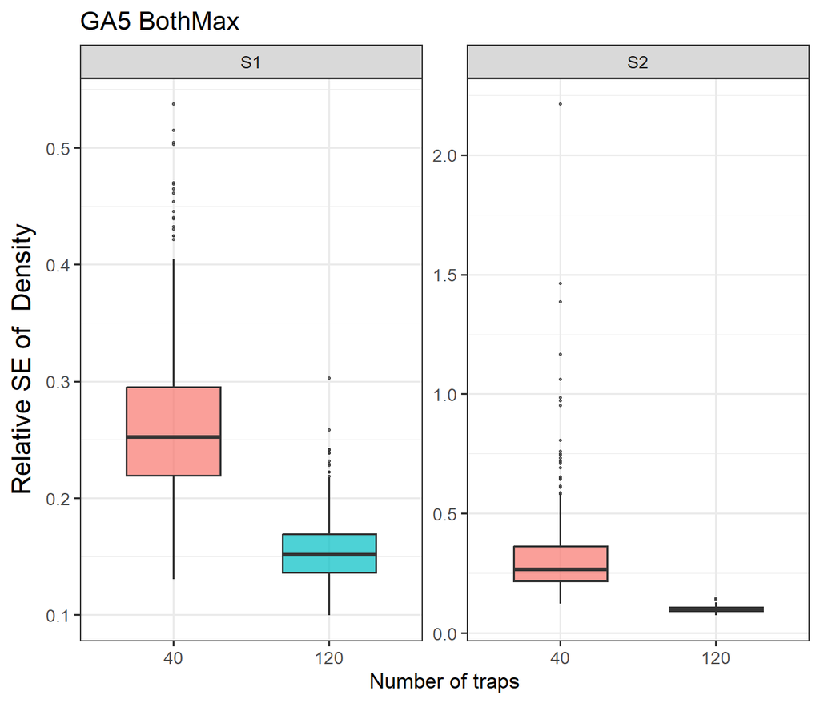

**λ₀**

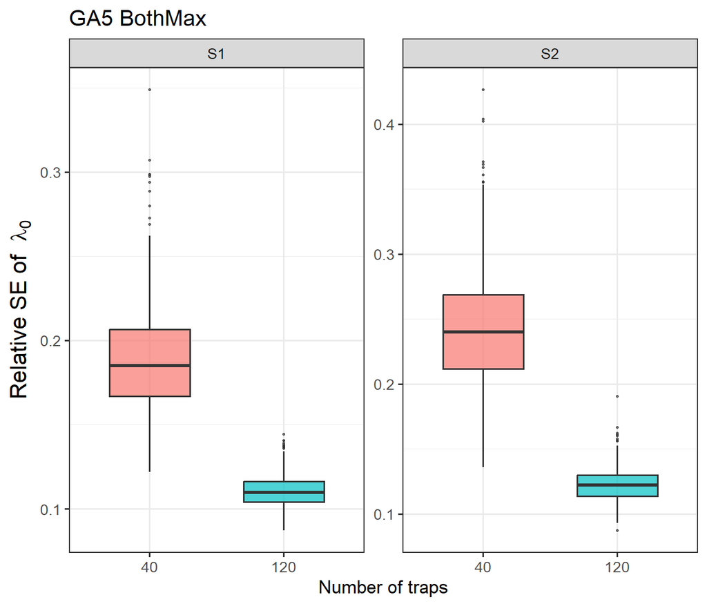

**σ**

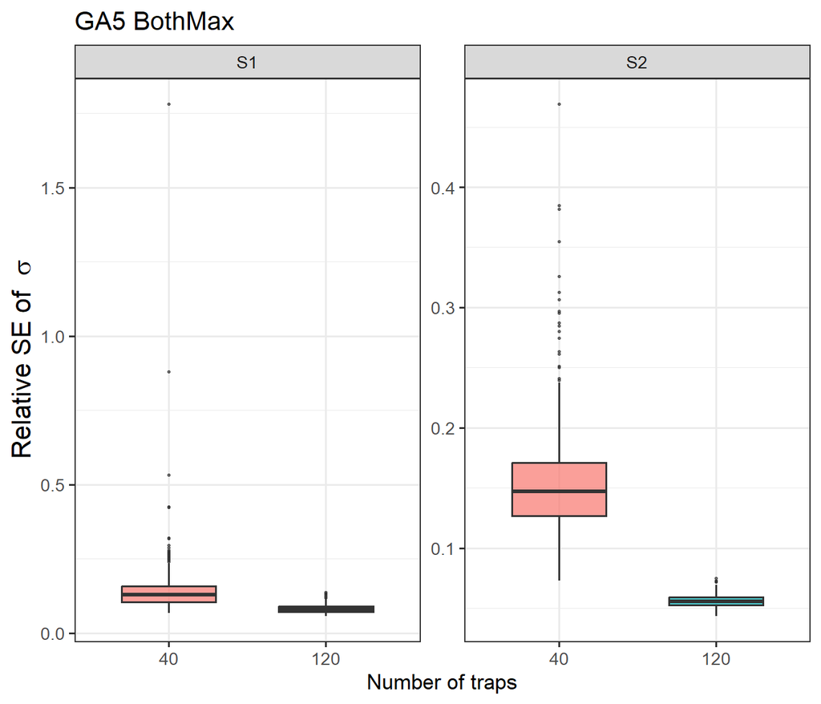

## Lacework

**Density**

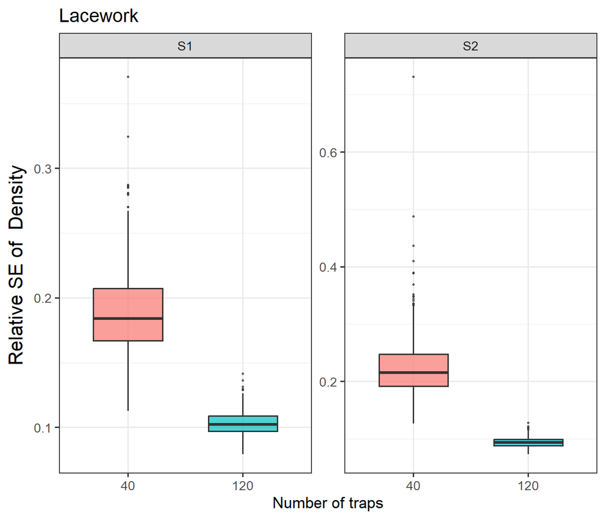

**λ₀**

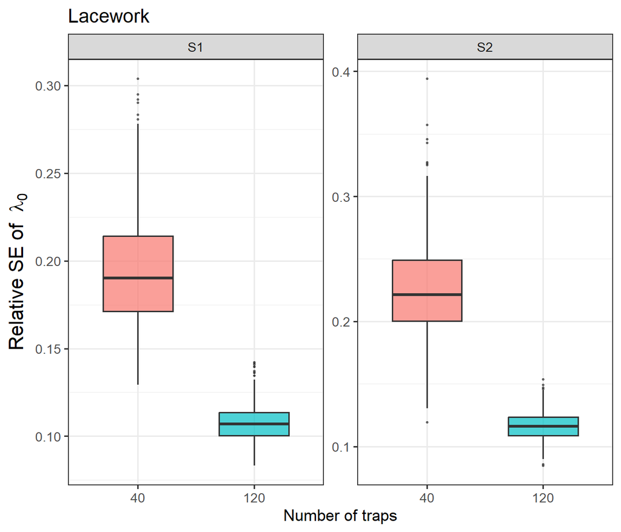

**σ**

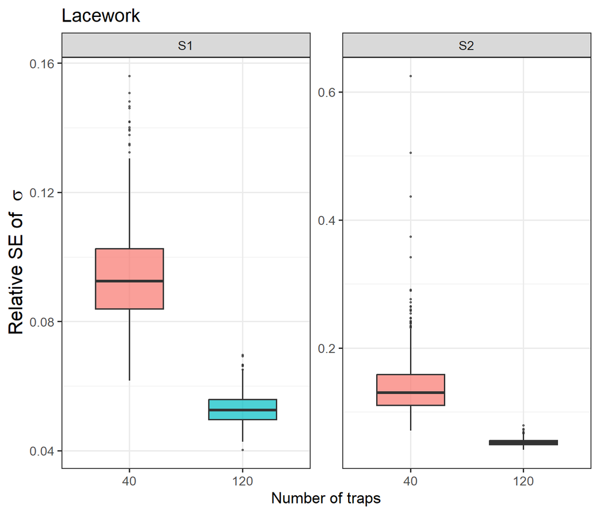

## General comments - precision

### Grids

- For 800 m spacing SE’s for all parameters skewed to the right (apart from S2 L0)
- Improved for 700 m spacing, some skewness for S2 D and S2 sigma.
- With 120 traps there are very few outliers, at 800 m spacing the most for S1 D and for 700 m spacing the most for S2 sigma

### Clusters

- OS spacing: skewness for S2 D and sigma (as with bias)
- 2 * sigma spacing: se’s quite tightly clustered for both strata and all parameters
- With 120 traps there are very few outliers for both spacings

### GA4

#### S1 values

- More positive skewness in D for S2, and slightly more for S1 in sigma ses
- With 120 traps there are very few outliers

#### S2 values

- Slight positive skewness in D for both strata, and more skew for S2 in sigma ses
- With 120 traps some skew for S1 D is evident

#### Avg values

- Positive skewness across parameters, more so for S1
- With 120 traps some skew for S1 D is evident with a few outliers for S1 sigma

#### Both values

- Some skew in S2 sigma but otherwise quite balanced
- Max-min similar
- With 120 traps tight dbns with few outliers, same for max-min

### GA5

#### S1 values

- More positive skewness in D for S2, and slightly more for S1 in sigma ses
- With 120 traps there are very few outliers

#### S2 values

- Slight positive skew in D and sigma (mainly for S2)
- With 120 traps very slight +ve skew in S1 D

#### Avg values

- Positive skewness in D, especially for S1
- Slight skew in other parameters across both strata
- Even with 120 traps substantial +ve skew in S1 D and some skew in S1 L0

#### Both values

- Very slight +ve skew in D for both, and sigma especially for S2
- Max-min more skew for S2 D, and for sigma both are slightly skew
- With 120 traps few outliers and mostly symmetrical dbns, with max-min a tiny bit more skewness in D and sigma for S1

### Lacework

- Very slight skew in D and sigma for S2
- With 120 traps few outliers and mostly symmetrical dbns